# OpenCLeaR: GPGPU-Accelerated MCMC Sampling

From Serial R Code to Hardware-Parallelized Markov Chains

OpenCLeaR Developer

2026-11-14

## Introduction: The Independent Parallel Chains (IPCs) Paradigm

Markov Chain Monte Carlo (MCMC) methods, particularly the Metropolis-Hastings (MH) algorithm, are foundational tools in Bayesian statistics for sampling from complex, unnormalized posterior distributions. However, by their mathematical definition, Markov chains are strictly sequential processes: the state at iteration $t+1$ depends directly on the state at iteration $t$. This inherent serialization represents a severe computational bottleneck on modern multi-core CPU and many-core GPGPU architectures.

To overcome this limitation without altering the target distribution, modern statistical computing leverages the **Independent Parallel Chains (IPCs)** paradigm. Instead of simulating a single, extremely long Markov chain on one execution thread, the total computational workload is split across $C$ independent processing units (cores or compute units). Each unit simulates an isolated Markov chain governed by its own pseudorandom number generator (RNG) stream and starting from distinct initial values.

Once execution finishes, the individual sub-chains are concatenated into a unified, high-density sample pool. This method belongs to the class of *task-parallel* or *embarrassingly parallel* problems because the chains require zero communication or synchronization during active sampling.

The mathematical advantages of the IPC approach are threefold: 1. **Asymptotic Convergence:** The aggregated sample pool retains the exact same asymptotic bias and stationary convergence properties as a single long chain. 2. **Space Exploration:** Simulating multiple independent paths simultaneously significantly mitigates the risk of a single chain getting trapped in a local energy minimum or single mode. 3. **Linear Speedup:** In an ideal, hardware-parallelized environment, generating $N$ total simulation steps across $C$ compute cores reduces the active wall-clock execution time by a factor of nearly $1/C$.

This vignette documents the architectural evolution of the IPC paradigm across five distinct engineering stages using a 2024 DELL XPS 17 system: * Stage 1: Pure serial R code (The non-parallelized baseline) * Stage 2: Subprocess parallelization via OS forking (`parallel::mclapply`) * Stage 3: Native serial C++ execution (`Rcpp`) * Stage 4: Multi-threaded CPU execution via Intel TBB (`RcppParallel`) * Stage 5: Hardware-abstracted GPGPU acceleration (`OpenCLeaR`)

### Hardware Diagnostic Baseline

To establish a verified baseline of the available compute layers on this workstation, we query the runtime environment:

```bash
clinfo -l
```

```r
GetDeviceList()
```

```
## |----------------.------------------------------------------------------------|
## | Device Index   | Device Name                                   | FP64       |
## |----------------+-----------------------------------------------+------------|
## |     0          | NVIDIA GeForce RTX 4080 Laptop GPU            | yes        |
## |     1          | Intel(R) Iris(R) Xe Graphics                  | no         |
## |     2          | cpu-haswell-13th Gen Intel(R) Core(TM) i9-139 | yes        |
## |     3          | 13th Gen Intel(R) Core(TM) i9-13900H          | yes        |
## |----------------'------------------------------------------------------------|
```

## 1. Mathematical Problem & Data Generation

We evaluate the performance of each execution engine by fitting a classic Bayesian normal distribution model where the observed data follows $y \sim N(\mu, \sigma)$. We place an uninformative normal prior on the mean parameter, $\mu \sim N(0, 10)$, and an uninformative Inverse-Gamma prior on the scale parameter, $\sigma \sim \text{Inverse-Gamma}(0.01, 0.01)$.

First, we generate a synthetic dataset consisting of $1,000$ independent draws from a true normal distribution with $\mu = 5.0$ and $\sigma = 2.0$:

```r
# Define simulation configurations: 1,000 chains simulating 1,000 steps each
total_samples <- 1000000L
num_chains <- 1000L
samples_per_chain <- as.integer(total_samples / num_chains)

set.seed(444)
raw_data <- rnorm(1000, mean = 5, sd = 2)
mu_empirical <- mean(raw_data)
sigma_empirical <- sd(raw_data)

# Extract a stable random seed to synchronize the initial states of the C++ and OpenCL engines
rng_state <- get(".Random.seed", envir = .GlobalEnv)
seed_base <- as.integer(rng_state[2])
```

## 2. The CPU Execution Engines

### 2.1. Pure Serial R Loop (Baseline)

The non-parallelized, loop-based R implementation executes all 1,000 chains sequentially on a single thread. This serves as our absolute baseline.

```r
run_mh_pure_r <- function(samples_per_chain, num_chains, raw_data, mu_init, sigma_init, seed_base) {
  total_size <- num_chains * samples_per_chain
  extracted_mu <- numeric(total_size)
  extracted_sigma <- numeric(total_size)

  for (c in 1:num_chains) {
    chain_offset <- (c - 1) * samples_per_chain
    set.seed(seed_base + ((c - 1) * 777))
    mu_current <- mu_init
    sigma_current <- sigma_init
    extracted_mu[chain_offset + 1] <- mu_current
    extracted_sigma[chain_offset + 1] <- sigma_current

    for (t in 2:samples_per_chain) {
      mu_proposal <- rnorm(1, mean = mu_current, sd = 0.05)
      sigma_proposal <- rnorm(1, mean = sigma_current, sd = 0.05)

      if (sigma_proposal <= 0.01) {
        extracted_mu[chain_offset + t] <- mu_current
        extracted_sigma[chain_offset + t] <- sigma_current
        next
      }

      log_prior_prop <- dnorm(mu_proposal, 0.0, 10.0, log = TRUE) +
                        dgamma(1 / sigma_proposal, shape = 0.01, scale = 1 / 0.01, log = TRUE)
      log_lik_prop <- sum(dnorm(raw_data, mu_proposal, sigma_proposal, log = TRUE))

      log_prior_curr <- dnorm(mu_current, 0.0, 10.0, log = TRUE) +
                        dgamma(1 / sigma_current, shape = 0.01, scale = 1 / 0.01, log = TRUE)
      log_lik_curr <- sum(dnorm(raw_data, mu_current, sigma_current, log = TRUE))

      if (log(runif(1)) < ((log_prior_prop + log_lik_prop) - (log_prior_curr + log_lik_curr))) {
        mu_current <- mu_proposal
        sigma_current <- sigma_proposal
      }
      extracted_mu[chain_offset + t] <- mu_current
      extracted_sigma[chain_offset + t] <- sigma_current
    }
  }
  return(list(mu = extracted_mu, sigma = extracted_sigma))
}
```

### 2.2. Subprocess Parallelization (`parallel::mclapply`)

This engine utilizes the native operating system `fork` mechanism via the `parallel` package. It distributes the independent chains across all available physical CPU threads, bypassing R’s single-threaded evaluation limitation.

```r
run_mh_r_subprocesses <- function(samples_per_chain, num_chains, raw_data, mu_init, sigma_init, seed_base) {
  cores_to_use <- parallel::detectCores()

  chain_results <- parallel::mclapply(1:num_chains, function(c) {
    set.seed(seed_base + ((c - 1) * 777))
    mu_curr <- mu_init
    sigma_curr <- sigma_init
    m_mu <- numeric(samples_per_chain)
    m_sigma <- numeric(samples_per_chain)
    m_mu[1] <- mu_curr
    m_sigma[1] <- sigma_curr

    for (t in 2:samples_per_chain) {
      mu_prop <- rnorm(1, mean = mu_curr, sd = 0.05)
      sigma_prop <- rnorm(1, mean = sigma_curr, sd = 0.05)

      if (sigma_prop <= 0.01) {
        m_mu[t] <- mu_curr
        m_sigma[t] <- sigma_curr
        next
      }

      log_prior_prop <- dnorm(mu_prop, 0.0, 10.0, log = TRUE) +
                        dgamma(1 / sigma_prop, shape = 0.01, scale = 1 / 0.01, log = TRUE) +
                        sum(dnorm(raw_data, mu_prop, sigma_prop, log = TRUE))

      log_prior_curr <- dnorm(mu_curr, 0.0, 10.0, log = TRUE) +
                        dgamma(1 / sigma_curr, shape = 0.01, scale = 1 / 0.01, log = TRUE) +
                        sum(dnorm(raw_data, mu_curr, sigma_curr, log = TRUE))

      if (log(runif(1)) < (log_prior_prop - log_prior_curr)) {
        mu_curr <- mu_prop
        sigma_curr <- sigma_prop
      }
      m_mu[t] <- mu_curr
      m_sigma[t] <- sigma_curr
    }
    return(list(mu = m_mu, sigma = m_sigma))
  }, mc.cores = cores_to_use)

  extracted_mu <- unlist(lapply(chain_results, function(x) x$mu))
  extracted_sigma <- unlist(lapply(chain_results, function(x) x$sigma))
  return(list(mu = extracted_mu, sigma = extracted_sigma))
}
```

### 2.3. Compiled C++ and Multi-Threaded TBB Engines (`Rcpp` / `RcppParallel`)

To eliminate the overhead of R’s interpreter loop, we compile a native serial C++ sampler alongside a multi-threaded C++ sampler that utilizes Intel Threading Building Blocks (TBB) via `RcppParallel`.

```r
Rcpp::sourceCpp(code = '
#include <RcppParallel.h>
#include <Rcpp.h>
#include <cmath>
#include <random>

// [[Rcpp::plugins(cpp17)]]
// [[Rcpp::depends(RcppParallel)]]

// Native serial CPU engine (1 Thread)
// [[Rcpp::export]]
Rcpp::List run_mh_rcpp_serial(int total_samples, int num_chains, Rcpp::NumericVector raw_data, double mu_init, double sigma_init, int seed_base) {
    int samples_per_chain = total_samples / num_chains;
    int data_len = raw_data.size();
    Rcpp::NumericVector extracted_mu(num_chains * samples_per_chain);
    Rcpp::NumericVector extracted_sigma(num_chains * samples_per_chain);

    for (int c = 0; c < num_chains; ++c) {
        int chain_offset = c * samples_per_chain;
        std::mt19937 cpu_mt(seed_base + (c * 777));
        std::normal_distribution<double> cpu_normal(0.0, 0.05);
        std::uniform_real_distribution<double> cpu_uniform(0.0, 1.0);

        double mu_current = mu_init;
        double sigma_current = sigma_init;
        extracted_mu[chain_offset] = mu_current;
        extracted_sigma[chain_offset] = sigma_current;

        for (int t = 1; t < samples_per_chain; ++t) {
            double mu_proposal    = mu_current + cpu_normal(cpu_mt);
            double sigma_proposal = sigma_current + cpu_normal(cpu_mt);

            if (sigma_proposal <= 0.01) {
                extracted_mu[chain_offset + t] = mu_current;
                extracted_sigma[chain_offset + t] = sigma_current;
                continue;
            }

            double log_prior_prop = R::dnorm(mu_proposal, 0.0, 10.0, true) + R::dgamma(1.0 / sigma_proposal, 0.01, 1.0 / 0.01, true);
            for (int d = 0; d < data_len; ++d) log_prior_prop += R::dnorm(raw_data[d], mu_proposal, sigma_proposal, true);

            double log_prior_curr = R::dnorm(mu_current, 0.0, 10.0, true) + R::dgamma(1.0 / sigma_current, 0.01, 1.0 / 0.01, true);
            for (int d = 0; d < data_len; ++d) log_prior_curr += R::dnorm(raw_data[d], mu_current, sigma_current, true);

            if (std::log(cpu_uniform(cpu_mt)) < (log_prior_prop - log_prior_curr)) {
                mu_current = mu_proposal;
                sigma_current = sigma_proposal;
            }
            extracted_mu[chain_offset + t] = mu_current;
            extracted_sigma[chain_offset + t] = sigma_current;
        }
    }
    return Rcpp::List::create(Rcpp::_["mu"] = extracted_mu, Rcpp::_["sigma"] = extracted_sigma);
}

// Multi-threaded CPU engine worker (Intel TBB)
struct ParallelMCMCSampler : public RcppParallel::Worker {
    int samples_per_chain; int data_len; RcppParallel::RVector<double> raw_data;
    double mu_init; double sigma_init; int seed_base;
    RcppParallel::RVector<double> extracted_mu; RcppParallel::RVector<double> extracted_sigma;

    ParallelMCMCSampler(int s, int d, Rcpp::NumericVector dv, double mi, double si, int bs, Rcpp::NumericVector om, Rcpp::NumericVector os)
        : samples_per_chain(s), data_len(d), raw_data(dv), mu_init(mi), sigma_init(si), seed_base(bs), extracted_mu(om), extracted_sigma(os) {}

    inline double thread_log_normal_pdf(double x, double m, double s) const { return -0.5 * std::log(2.0 * M_PI) - std::log(s) - 0.5 * std::pow((x - m) / s, 2.0); }
    inline double thread_log_invgamma_pdf(double x, double a, double b) const { return a * std::log(b) - std::lgamma(a) - (a + 1.0) * std::log(x) - (b / x); }

    void operator()(std::size_t begin_chain, std::size_t end_chain) {
        for (std::size_t c = begin_chain; c < end_chain; ++c) {
            int chain_offset = c * samples_per_chain;
            std::mt19937 cpu_mt(seed_base + (c * 777));
            std::normal_distribution<double> cpu_normal(0.0, 0.05);
            std::uniform_real_distribution<double> cpu_uniform(0.0, 1.0);

            double mu_current = mu_init; double sigma_current = sigma_init;
            extracted_mu[chain_offset] = mu_current; extracted_sigma[chain_offset] = sigma_current;

            for (int t = 1; t < samples_per_chain; ++t) {
                double mu_proposal    = mu_current + cpu_normal(cpu_mt);
                double sigma_proposal = sigma_current + cpu_normal(cpu_mt);
                if (sigma_proposal <= 0.01001) { extracted_mu[chain_offset + t] = mu_current; extracted_sigma[chain_offset + t] = sigma_current; continue; }

                double log_prior_prop = thread_log_normal_pdf(mu_proposal, 0.0, 10.0) + thread_log_invgamma_pdf(sigma_proposal, 0.01, 1.0 / 0.01);
                for (int d = 0; d < data_len; ++d) log_prior_prop += thread_log_normal_pdf(raw_data[d], mu_proposal, sigma_proposal);

                double log_prior_curr = thread_log_normal_pdf(mu_current, 0.0, 10.0) + thread_log_invgamma_pdf(sigma_current, 0.01, 1.0 / 0.01);
                for (int d = 0; d < data_len; ++d) log_prior_curr += thread_log_normal_pdf(raw_data[d], mu_current, sigma_current);

                if (std::log(cpu_uniform(cpu_mt)) < (log_prior_prop - log_prior_curr)) { mu_current = mu_proposal; sigma_current = sigma_proposal; }
                extracted_mu[chain_offset + t] = mu_current; extracted_sigma[chain_offset + t] = sigma_current;
            }
        }
    }
};

// [[Rcpp::export]]
Rcpp::List run_mh_rcpp_parallel(int total_samples, int num_chains, Rcpp::NumericVector raw_data, double mu_init, double sigma_init, int seed_base) {
    int samples_per_chain = total_samples / num_chains;
    Rcpp::NumericVector extracted_mu(num_chains * samples_per_chain); Rcpp::NumericVector extracted_sigma(num_chains * samples_per_chain);
    ParallelMCMCSampler worker(samples_per_chain, raw_data.size(), raw_data, mu_init, sigma_init, seed_base, extracted_mu, extracted_sigma);
    RcppParallel::parallelFor(0, num_chains, worker);
    return Rcpp::List::create(Rcpp::_["mu"] = extracted_mu, Rcpp::_["sigma"] = extracted_sigma);
}
')
```

## 3. The GPGPU Execution Engine (OpenCLeaR)

The `OpenCLeaR` engine binds an OpenCL C hardware kernel to a persistent C++ memory interface via the `oclFunction` JIT-compiler pipeline.

During package deployment, these resources are permanently stored within the package structure and can be compiled without directory prefixes. For interactive development or local modifications, you can target local files using relative paths like `./mh_sampler.cl` and `./mh_sampler.cpp`. Here, we pass the parameters directly to a double closure IIFE to preserve the compiled binary pointers in the active R session.

### 3.1. Standard Double-Precision GPU Engine (FP64 Mode)

Prepare the OpencL kerenl interface:

```r
mcmc_interface_src <- '// Rcpp function body
int total_samples = as<int>(n_samples);
int chains        = as<int>(n_chains);
int samples_per_chain = total_samples / chains;

NumericVector r_data(data_vector);
int data_len = r_data.size();
int total_output_size = chains * samples_per_chain;

NumericVector out_mu(total_output_size);
NumericVector out_sigma(total_output_size);

Environment e = Environment::global_env();
std::vector<int> r_seed = e[".Random.seed"];
int base_seed = r_seed[r_seed[1] + 1];

Memory<real> GpuData(*device, data_len);
Memory<real> GpuMu(*device, total_output_size);
Memory<real> GpuSigma(*device, total_output_size);

for(int i = 0; i < data_len; ++i) GpuData[i] = (real)r_data[i];

GpuData.write_to_device();

real mu_init_typed       = as<real>(mu_init);
real sigma_init_typed    = as<real>(sigma_init);
real prop_sd_mu_typed    = (real)0.05f;
real prop_sd_sigma_typed = (real)0.05f;

Kernel mh_kernel(*device, chains, "mh_sampler_kernel",
                 GpuMu, GpuSigma, GpuData, data_len, samples_per_chain, chains,
                 mu_init_typed, sigma_init_typed, prop_sd_mu_typed, prop_sd_sigma_typed, base_seed);

mh_kernel.run();

GpuMu.read_from_device();
GpuSigma.read_from_device();

for(int i = 0; i < total_output_size; ++i) {
    out_mu[i]    = GpuMu[i];
    out_sigma[i] = GpuSigma[i];
}

Function f("runif"); f(1);

return List::create(
    _["mu"]    = out_mu,
    _["sigma"] = out_sigma
);'
writeLines(mcmc_interface_src, "./mh_sampler.cpp")
```

Register the OpenCL kernel object via `oclFunction`.

```r
if (getRversion() >= "2.15.1") {
  utils::globalVariables(".parallel_mh_sampler_internal")
}
```

```
## [1] ".parallel_mh_sampler_internal"
```

```r
parallel_MH_sampler <- (function() {
    .parallel_mh_sampler_internal <- NULL
    function(n_samples, n_chains, data_vector, mu_init, sigma_init) {
        if (is.null(.parallel_mh_sampler_internal)) {
            .parallel_mh_sampler_internal <<- oclFunction(
                signature = methods::signature(
                                         n_samples   = "integer",
                                         n_chains    = "integer",
                                         data_vector = "numeric",
                                         mu_init     = "numeric",
                                         sigma_init  = "numeric"
                                     ),
                kernel_file     = "./mh_sampler.cl",
                interface_file  = "./mh_sampler.cpp"
            )
        }
        return(.parallel_mh_sampler_internal(n_samples, n_chains, data_vector, mu_init, sigma_init))
    }
})()
```

### 3.2. Single-Precision Forced GPU Engine (FP32 Mode)

To enable execution on consumer graphics cards that lack dedicated double-precision FP64 compute clusters, `OpenCLeaR` provides a runtime flag `force_float = TRUE`. This flag forces the JIT compiler to remap the abstract type `real` to standard 32-bit floating-point structures.

```r
if (getRversion() >= "2.15.1") {
  utils::globalVariables(".parallel_mh_sampler_float_internal")
}
```

```
## [1] ".parallel_mh_sampler_internal"       ".parallel_mh_sampler_float_internal"
```

```r
parallel_MH_sampler_float <- (function() {
    .parallel_mh_sampler_float_internal <- NULL
    function(n_samples, n_chains, data_vector, mu_init, sigma_init) {
        if (is.null(.parallel_mh_sampler_float_internal)) {
            .parallel_mh_sampler_float_internal <<- oclFunction(
                signature = methods::signature(
                                         n_samples   = "integer",
                                         n_chains    = "integer",
                                         data_vector = "numeric",
                                         mu_init     = "numeric",
                                         sigma_init  = "numeric"
                                     ),
                kernel_file     = "./mh_sampler.cl",
                interface_file  = "./mh_sampler.cpp",
                force_float     = TRUE
            )
        }
        return(.parallel_mh_sampler_float_internal(n_samples, n_chains, data_vector, mu_init, sigma_init))
    }
})()
```

## 4. Benchmarking & Quantified Evaluation

```r
# --- COLDSTART ELIMINATION / WARM-UP ---
invisible(run_mh_pure_r(2L, 10L, raw_data, mu_empirical, sigma_empirical, seed_base))
invisible(run_mh_r_subprocesses(2L, 10L, raw_data, mu_empirical, sigma_empirical, seed_base))
invisible(run_mh_rcpp_parallel(20L, 10L, raw_data, mu_empirical, sigma_empirical, seed_base))
ActivateDevice(0)
```

```
## [1] TRUE
```

```r
invisible(parallel_MH_sampler(as.integer(100), as.integer(100), raw_data, mu_empirical, sigma_empirical))
```

```
##  [OpenCLeaR Runtime] hardware change or float/double mode change detected! recompile ...
## 🔄 [CRITICAL-DEBUG] /home/alge/R/x86_64-pc-linux-gnu-library/4.6/OpenCLeaR/bin/ocl_compiler -k . -i ././mh_sampler.cl -c ./.cl_cache -p 0 -d 0 -l /home/alge/R/x86_64-pc-linux-gnu-library/4.6/OpenCLeaR/kernel/libkernel.cl
```

```r
invisible(parallel_MH_sampler_float(as.integer(100), as.integer(100), raw_data, mu_empirical, sigma_empirical))
```

```
##  [OpenCLeaR Runtime] hardware change or float/double mode change detected! recompile ...
## 🔄 [CRITICAL-DEBUG] /home/alge/R/x86_64-pc-linux-gnu-library/4.6/OpenCLeaR/bin/ocl_compiler -k . -i ././mh_sampler.cl -c ./.cl_cache -p 0 -d 0 -l /home/alge/R/x86_64-pc-linux-gnu-library/4.6/OpenCLeaR/kernel/libkernel.cl -f
```

```r
ActivateDevice(1)
```

```
## [1] TRUE
```

```r
invisible(parallel_MH_sampler(as.integer(100), as.integer(100), raw_data, mu_empirical, sigma_empirical))
```

```
##  [OpenCLeaR Runtime] hardware change or float/double mode change detected! recompile ...
## 🔄 [CRITICAL-DEBUG] /home/alge/R/x86_64-pc-linux-gnu-library/4.6/OpenCLeaR/bin/ocl_compiler -k . -i ././mh_sampler.cl -c ./.cl_cache -p 1 -d 0 -l /home/alge/R/x86_64-pc-linux-gnu-library/4.6/OpenCLeaR/kernel/libkernel.cl -f
```

```r
ActivateDevice(2)
```

```
## [1] TRUE
```

```r
invisible(parallel_MH_sampler(as.integer(100), as.integer(100), raw_data, mu_empirical, sigma_empirical))
```

```
##  [OpenCLeaR Runtime] hardware change or float/double mode change detected! recompile ...
## 🔄 [CRITICAL-DEBUG] /home/alge/R/x86_64-pc-linux-gnu-library/4.6/OpenCLeaR/bin/ocl_compiler -k . -i ././mh_sampler.cl -c ./.cl_cache -p 2 -d 0 -l /home/alge/R/x86_64-pc-linux-gnu-library/4.6/OpenCLeaR/kernel/libkernel.cl
```

```r
invisible(parallel_MH_sampler_float(as.integer(100), as.integer(100), raw_data, mu_empirical, sigma_empirical))
```

```
##  [OpenCLeaR Runtime] hardware change or float/double mode change detected! recompile ...
## 🔄 [CRITICAL-DEBUG] /home/alge/R/x86_64-pc-linux-gnu-library/4.6/OpenCLeaR/bin/ocl_compiler -k . -i ././mh_sampler.cl -c ./.cl_cache -p 2 -d 0 -l /home/alge/R/x86_64-pc-linux-gnu-library/4.6/OpenCLeaR/kernel/libkernel.cl -f
```

### 4.1. Serial R Loop

```r
timer_start <- Sys.time()
output_r    <- run_mh_pure_r(samples_per_chain, num_chains, raw_data, mu_empirical, sigma_empirical, seed_base)
time_pure_r <- as.numeric(difftime(Sys.time(), timer_start, units = "secs"))
```

### 4.2. Multicore R Subprocesses

```r
timer_start <- Sys.time()
output_mcl  <- run_mh_r_subprocesses(samples_per_chain, num_chains, raw_data, mu_empirical, sigma_empirical, seed_base)
time_mcl    <- as.numeric(difftime(Sys.time(), timer_start, units = "secs"))
```

### 4.3. Serial C++ Kernel

```r
timer_start <- Sys.time()
output_spp  <- run_mh_rcpp_serial(total_samples, num_chains, raw_data, mu_empirical, sigma_empirical, seed_base)
time_serial <- as.numeric(difftime(Sys.time(), timer_start, units = "secs"))
```

### 4.4. Parallel C++ TBB Engine

```r
timer_start <- Sys.time()
output_tbb  <- run_mh_rcpp_parallel(total_samples, num_chains, raw_data, mu_empirical, sigma_empirical, seed_base)
time_tbb    <- as.numeric(difftime(Sys.time(), timer_start, units = "secs"))
```

### 4.5. OpenCLeaR GPGPU Pipeline

Default behaviuor, NVidia GPU uses ‘double’

```r
ActivateDevice(0)
```

```
## [1] TRUE
```

```r
GetActiveDeviceInfo()
```

```
## |----------------.------------------------------------------------------------|
## | Device Index   | 0                                                          |
## | Platform ID    | 0                                                          |
## | Device ID      | 0                                                          |
## | Device Name    | NVIDIA GeForce RTX 4080 Laptop GPU                         |
## | Device Vendor  | NVIDIA Corporation                                         |
## | Device Driver  | 615.71.09 (Linux)                                          |
## | OpenCL Version | OpenCL C 3.0                                               |
## | Compute Units  | 58 at 1350 MHz (7424 cores, 20.045 TFLOPs/s)               |
## | Memory, Cache  | 11956 MB VRAM, 1624 KB global / 48 KB local                |
## | Buffer Limits  | 2989 MB global, 64 KB constant                             |
## | FP64 capable   | TRUE                                                       |
## |----------------'------------------------------------------------------------|
```

```r
timer_start <- Sys.time()
output_gpu  <- parallel_MH_sampler(as.integer(total_samples), as.integer(num_chains), raw_data, mu_empirical, sigma_empirical)
time_gpu    <- as.numeric(difftime(Sys.time(), timer_start, units = "secs"))
```

Now we force the NVidia GPU into ‘float’ mode

```r
timer_start <- Sys.time()
output_gpu_float  <- parallel_MH_sampler_float(as.integer(total_samples), as.integer(num_chains), raw_data, mu_empirical, sigma_empirical)
time_gpu_float    <- as.numeric(difftime(Sys.time(), timer_start, units = "secs"))
```

Switch device to next index, Intel Xe GPU uses ‘float’

```r
ActivateDevice(1)
```

```
## [1] TRUE
```

```r
GetActiveDeviceInfo()
```

```
## |----------------.------------------------------------------------------------|
## | Device Index   | 1                                                          |
## | Platform ID    | 1                                                          |
## | Device ID      | 0                                                          |
## | Device Name    | Intel(R) Iris(R) Xe Graphics                               |
## | Device Vendor  | Intel(R) Corporation                                       |
## | Device Driver  | 23.43.027642 (Linux)                                       |
## | OpenCL Version | OpenCL C 3.0                                               |
## | Compute Units  | 96 at 1500 MHz (768 cores, 2.304 TFLOPs/s)                 |
## | Memory, Cache  | 59695 MB RAM, 2880 KB global / 64 KB local                 |
## | Buffer Limits  | 4095 MB global, 4194296 KB constant                        |
## | FP64 capable   | FALSE                                                      |
## |----------------'------------------------------------------------------------|
```

```r
timer_start <- Sys.time()
output_intel_gpu  <- parallel_MH_sampler(as.integer(total_samples), as.integer(num_chains), raw_data, mu_empirical, sigma_empirical)
time_intel_gpu    <- as.numeric(difftime(Sys.time(), timer_start, units = "secs"))
```

Switch device to next index, Intel Core i9 CPU using the POCL driver

```r
ActivateDevice(2)
```

```
## [1] TRUE
```

```r
GetActiveDeviceInfo()
```

```
## |----------------.------------------------------------------------------------|
## | Device Index   | 2                                                          |
## | Platform ID    | 2                                                          |
## | Device ID      | 0                                                          |
## | Device Name    | cpu-haswell-13th Gen Intel(R) Core(TM) i9-13900H           |
## | Device Vendor  | GenuineIntel                                               |
## | Device Driver  | 5.0+debian (Linux)                                         |
## | OpenCL Version | OpenCL C 3.0                                               |
## | Compute Units  | 20 at 3001 MHz (10 cores, 0.96 TFLOPs/s)                   |
## | Memory, Cache  | 61936 MB RAM, 24576 KB global / 1280 KB local              |
## | Buffer Limits  | 16384 MB global, 1280 KB constant                          |
## | FP64 capable   | TRUE                                                       |
## |----------------'------------------------------------------------------------|
```

```r
timer_start <- Sys.time()
output_cpu  <- parallel_MH_sampler(as.integer(total_samples), as.integer(num_chains), raw_data, mu_empirical, sigma_empirical)
time_cpu    <- as.numeric(difftime(Sys.time(), timer_start, units = "secs"))
```

Now we force also the CPU into ‘float’ mode

```r
timer_start <- Sys.time()
output_cpu_float  <- parallel_MH_sampler_float(as.integer(total_samples), as.integer(num_chains), raw_data, mu_empirical, sigma_empirical)
time_cpu_float    <- as.numeric(difftime(Sys.time(), timer_start, units = "secs"))
```

## 5. Convergence Diagnostics & Visualizations

GPGPU speedups are only scientifically relevant if numeric integrity is preserved perfectly. We extract the sampled data vectors from the graphic card memory and generate posterior density distributions and convergence traceplots.

### 5.1. Performance & Validation Matrix

Execution Metrics and Parameter Validation on XPS 17 (True Mu = 5.01, True Sigma = 2.02)

| Engine | Precision | Runtime | Speedup | Mu_Hat | Sigma_Hat |
| --- | --- | --- | --- | --- | --- |
| 🔴 Pure R Script (1 Core) | Double | 33.9224s | 1.00x (Baseline) | 5.0084 | 2.0273 |
| 🟤 R Subprocesses (mclapply Multi) | Double | 3.7741s | 8.99x | 5.0084 | 2.0273 |
| 🟠 Native C++ Kernel (1 Thread) | Double | 10.0568s | 3.37x | 5.0086 | 2.0275 |
| 🟡 RcppParallel TBB (CPU Threads) | Double | 0.9982s | 33.98x | 5.0085 | 2.0760 |
| 🚀 OpenCLeaR: NVIDIA GPU (Dev 0) double | Double | 2.7837s | 12.19x | 5.0085 | 2.0757 |
| 🚀 OpenCLeaR: NVIDIA GPU (Dev 0) float | Float | 0.3787s | 89.58x | 5.0089 | 2.0759 |
| 🚀 OpenCLeaR: Intel GPU (Dev 1) float | Float | 0.9544s | 35.54x | 5.0080 | 2.0759 |
| 🚀 OpenCLeaR: Intel CPU (Dev 2) POCL double | Double | 9.0638s | 3.74x | 5.0085 | 2.0760 |
| 🚀 OpenCLeaR: Intel CPU (Dev 2) POCL float | Float | 8.4226s | 4.03x | 5.0084 | 2.0760 |

### 5.2. Posterior Density Identifications

We evaluate the sampled posterior landscapes of parameter $\mu$ (Target: ~5.01) and parameter $\sigma$ (Target: ~2.02) against empirical baselines.

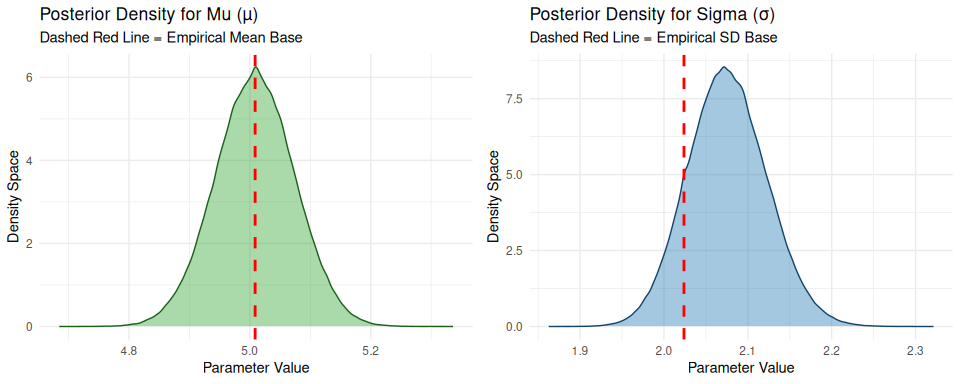

```r
# We use the double-precision NVIDIA output for validation
visualization_df <- data.frame(
  mu    = output_gpu$mu,
  sigma = output_gpu$sigma
)

# Density map for Mu (µ)
plot_mu <- ggplot(visualization_df, aes(x = mu)) +
  geom_density(fill = "#2ca02c", alpha = 0.4, color = "#1a601a") +
  geom_vline(xintercept = mu_empirical, linetype = "dashed", color = "red", linewidth = 1) +
  labs(title = "Posterior Density for Mu (µ)",
       subtitle = "Dashed Red Line = Empirical Mean Base",
       x = "Parameter Value", y = "Density Space") +
  theme_minimal()

# Density map for Sigma (σ)
plot_sigma <- ggplot(visualization_df, aes(x = sigma)) +
  geom_density(fill = "#1f77b4", alpha = 0.4, color = "#11456b") +
  geom_vline(xintercept = sigma_empirical, linetype = "dashed", color = "red", linewidth = 1) +
  labs(title = "Posterior Density for Sigma (σ)",
       subtitle = "Dashed Red Line = Empirical SD Base",
       x = "Parameter Value", y = "Density Space") +
  theme_minimal()

grid.arrange(plot_mu, plot_sigma, ncol = 2)
```

### 5.3. MCMC Traceplots (Chain Mixing Verification)

To verify the mixing properties of the parallelized chains generated across the OpenCL compute units, we extract the structural path tracks of the first three chains.

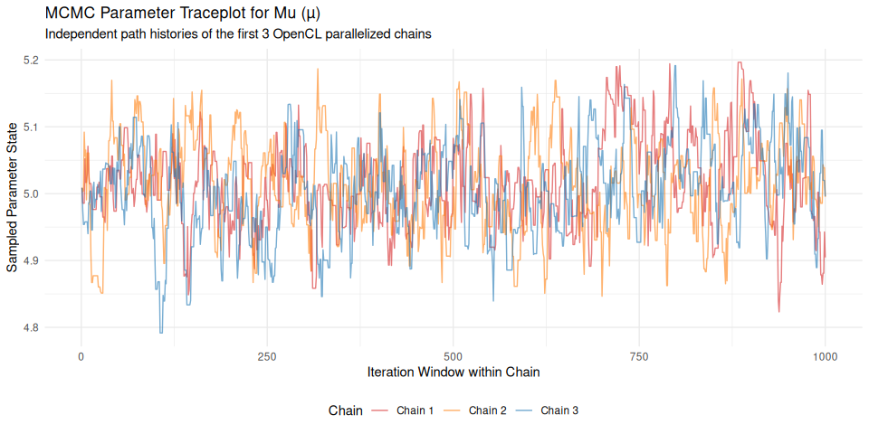

```r
index_steps <- 1:samples_per_chain

traceplot_df <- data.frame(
  Iteration = rep(index_steps, 3),
  Chain     = rep(c("Chain 1", "Chain 2", "Chain 3"), each = samples_per_chain),
  Mu_Value  = c(output_gpu$mu[1:samples_per_chain],
                output_gpu$mu[(samples_per_chain + 1):(2 * samples_per_chain)],
                output_gpu$mu[(2 * samples_per_chain + 1):(3 * samples_per_chain)])
)

ggplot(traceplot_df, aes(x = Iteration, y = Mu_Value, color = Chain)) +
  geom_line(alpha = 0.6) +
  scale_color_manual(values = c("#d62728", "#ff7f0e", "#1f77b4")) +
  labs(title = "MCMC Parameter Traceplot for Mu (µ)",
       subtitle = "Independent path histories of the first 3 OpenCL parallelized chains",
       x = "Iteration Window within Chain", y = "Sampled Parameter State") +
  theme_minimal() +
  theme(legend.position = "bottom")
```

## Cache maintenance

These are the OpenCL kernel binaries generated above. You may simply cleanup via:

```r
CleanCLCache()
```

## Conclusion

Note that here we use mobile consumer GPUs lacking the features of high performance server GPUs. On such systems maybe it could outperform the CPU hardware even in ‘double’ mode. Moreover the portable OpenCL driver (POCL) approach as used for the CPU seems to get no advances even over the simple `mclapply` method. But nevertheless it enables otherwise OpenCL device free computers being used as a convenient developer platform for this type of software which later can run on much more powerful systems without change. For some reasons intels oneapi driver only recognises the CPU from time to time, so this test is disabled for now.